# Seaborn

Seaborn visualisasi data statistic Seaborn adalah perpustakaan visualisasi data Python berdasarkan matplotlib. Ini menyediakan antarmuka tingkat tinggi untuk menggambar grafik statistik yang menarik dan informatif. Seaborn adalah perpustakaan untuk membuat grafik statistik dengan Python. Itu dibangun di atas matplotlib dan terintegrasi dengan struktur data panda.

Berikut adalah beberapa fungsi yang ditawarkan seaborn: • API berorientasi dataset untuk memeriksa hubungan antara beberapa variabel • Dukungan khusus untuk menggunakan variabel kategori untuk menunjukkan pengamatan atau statistik agregat • Opsi untuk memvisualisasikan distribusi univariat atau bivariat dan untuk membandingkannya di antara subset data • Estimasi otomatis dan ploting model regresi linier untuk berbagai jenis variabel dependen • Tampilan nyaman ke struktur keseluruhan dataset kompleks • Abstraksi tingkat tinggi untuk penataan grid multi-plot yang memungkinkan Anda membangun visualisasi yang kompleks dengan mudah • Kontrol ringkas atas gaya gambar matplotlib dengan beberapa tema bawaan • Alat untuk memilih palet warna yang dengan setia mengungkapkan pola dalam data Anda Seaborn bertujuan menjadikan visualisasi sebagai bagian sentral dari penjelajahan dan pemahaman data. Fungsi plot yang berorientasi pada dataset beroperasi pada kerangka data dan array yang berisi seluruh dataset dan secara internal melakukan pemetaan semantik yang diperlukan dan agregasi statistik untuk menghasilkan plot informatif.

Contoh:

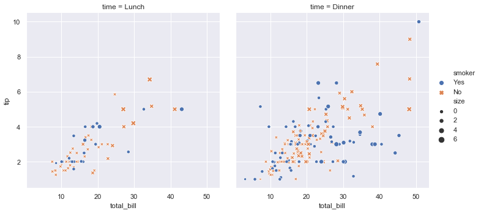

```python
import seaborn as sns
sns.set()
tips = sns.load_dataset("tips")
sns.relplot(x="total_bill", y="tip", col="time",
            hue="smoker", style="smoker", size="size",
            data=tips);
```

Abstraksi API lintas visualisasi Tidak ada cara universal terbaik untuk memvisualisasikan data. Berbagai pertanyaan dijawab dengan berbagai jenis visualisasi. Seaborn mencoba membuatnya mudah untuk beralih di antara representasi visual yang berbeda yang dapat diparameterisasi dengan API berorientasi dataset yang sama. Fungsi relplot () dinamai demikian karena ia dirancang untuk memvisualisasikan banyak hubungan statistik yang berbeda. Sementara sebar plot adalah cara yang sangat efektif untuk melakukan hal ini, hubungan di mana satu variabel mewakili ukuran waktu lebih baik diwakili oleh garis. Fungsi relplot () memiliki parameter jenis yang mudah digunakan untuk memudahkan Anda beralih ke representasi alternatif ini:

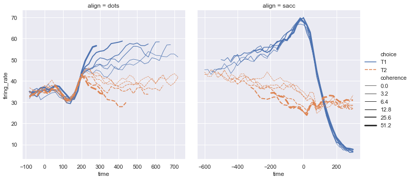

```python
dots = sns.load_dataset("dots")
sns.relplot(x="time", y="firing_rate", col="align",
            hue="choice", size="coherence", style="choice",
            facet_kws=dict(sharex=False),
            kind="line", legend="full", data=dots);
```

Perhatikan bagaimana parameter ukuran dan gaya dibagi di seluruh plot sebar dan garis, tetapi keduanya memengaruhi dua visualisasi secara berbeda (mengubah area penanda dan simbol vs lebar dan garis putus-putus).

Estimasi statistik dan bar kesalahan Seringkali kita tertarik pada nilai rata-rata dari satu variabel sebagai fungsi dari variabel lain. Banyak fungsi seaborn dapat secara otomatis melakukan estimasi statistik yang diperlukan untuk menjawab pertanyaan-pertanyaan ini

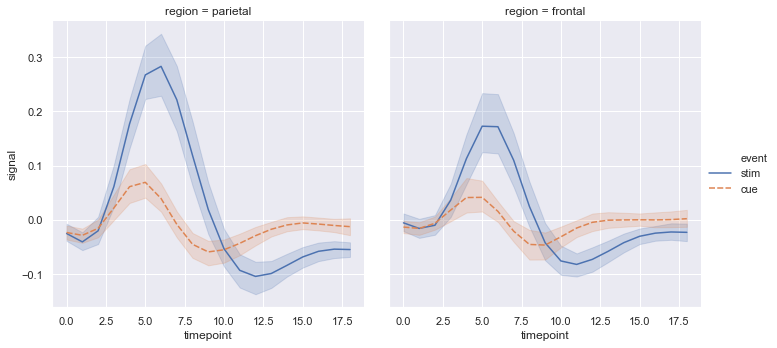

```python
mri = sns.load_dataset("fmri")
sns.relplot(x="timepoint", y="signal", col="region",
            hue="event", style="event",
            kind="line",data=mri);
```

Ketika nilai statistik diperkirakan, seaborn akan menggunakan bootstrap untuk menghitung interval kepercayaan dan menggambar bar kesalahan yang mewakili ketidakpastian estimasi.

Estimasi statistik di seaborn melampaui statisitika deskriptif. Sebagai contoh, dimungkinkan juga untuk meningkatkan sebar untuk memasukkan model regresi linier (dan ketidakpastiannya) menggunakan lmplot ():

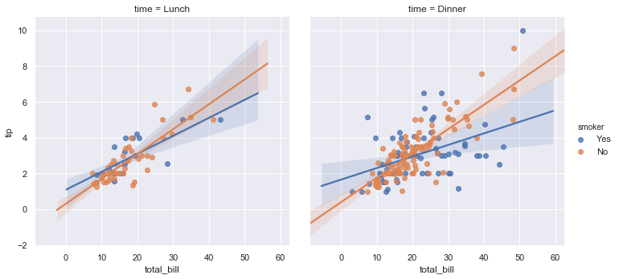

```python
sns.lmplot(x="total_bill", y="tip", col="time", hue="smoker",
           data=tips);
```